# Factors associated with COVID-19 vaccine coverage in chronic kidney disease patients

$$\\[0.05in]$$

#### Background

Chronic kidney disease (CKD) is a significant risk factor for COVID-19-related mortality. Although vaccination has the potential to mitigate this risk, CKD has been linked with impaired COVID-19 vaccine immunogenicity and high rates of breakthrough infection among individuals who have received a 2-dose primary vaccine series.

Vaccine recommendations for CKD patients in the UK have evolved over time (see [protocol](https://docs.google.com/document/d/1w48W-bCMfn0RdkfxlU6fbRkPv3MnIYd3/edit#heading=h.1fob9te). Relative uptake of different vaccines in this population remains uncertain, as does the relative vaccine effectiveness (VE) of different regimens, including homologous versus heterologous vaccine usage. This project seeks to address these key evidence gaps.

#### Inclusion criteria

- Registered for at least 3m before index date (01-Dec-2020)
- Alive on index date
- Aged ≥16 and <120 on index date
- eGFR<60 in 2 years before 01 Dec 2020 OR dialysis code (opensafely/dialysis/3ce108ac) OR kidney transplant code (opensafely/kidney-transplant//2020-07-15)
- No missing demographic data
- Maximum of 4 COVID-19 doses recorded
- No vaccines administered at an interval of <14 days

A total of **8,840** (rounded to the nearest 5) met the inclusion criteria (see *output/data/flowchart.csv* for additional details).
NB: Dummy data processing flag detected!
$$\\[0.05in]$$

#### Table 1: Summary of population

| Variable | Count<sup>1</sup> | Percent |
| --- | --- | --- |
| Age |  |  |
| 16-69 | 6170 | 69.8 |
| 70-79 | 2100 | 23.8 |
| 80-89 | 470 | 5.3 |
| 90+ | 95 | 1.1 |
| Sex |  |  |
| Female | 4630 | 52.4 |
| Male | 4210 | 47.6 |
| Ethnicity |  |  |
| White | 1750 | 19.8 |
| Mixed | 1685 | 19.1 |
| Asian or Asian British | 1675 | 18.9 |
| Black or Black British | 1655 | 18.7 |
| Other ethnic groups | 1615 | 18.3 |
| Unknown | 465 | 5.3 |
| IMD |  |  |
| 1 most deprived | 1845 | 20.9 |
| 2 | 1770 | 20 |
| 3 | 1770 | 20 |
| 4 | 1790 | 20.2 |
| 5 least deprived | 1665 | 18.8 |
| Region |  |  |
| London | 1820 | 20.6 |
| East of England | 890 | 10.1 |
| East Midlands | 905 | 10.2 |
| North East | 925 | 10.5 |
| North West | 845 | 9.6 |
| South East | 870 | 9.8 |
| South West | 905 | 10.2 |
| West Midlands | 860 | 9.7 |
| Yorkshire and the Humber | 830 | 9.4 |
| JCVI group |  |  |
| 1 (care home residents/staff) | 1805 | 20.4 |
| 2 (80+ or health/social care worker) | 1730 | 19.6 |
| 3 (75+) | 260 | 2.9 |
| 4 (70+ or clinically extremely vulnerable) | 1735 | 19.6 |
| 5 (65+) | 270 | 3.1 |
| 6 (16-65 and clinically vulnerable) | 3040 | 34.4 |
| Urban/rural |  |  |
| Urban conurbation | 2215 | 25.1 |
| Urban city or town | 2215 | 25.1 |
| Rural town or village | 4415 | 49.9 |
| Clinical (CKD-related) |  |  |
| CKD diagnostic code | 1805 | 20.4 |
| Dialysis | 4795 | 54.2 |
| Kidney transplant | 4800 | 54.3 |
| CKD stage 3-5 code | 1815 | 20.5 |
| Other |  |  |
| Clinically extremely vulnerable | 2650 | 30 |
| Care home resident | 1805 | 20.4 |
| End of life care | 1850 | 20.9 |
| Housebound | 1745 | 19.7 |
| Current or former smoker | 1255 | 14.2 |
| Asthma | 1780 | 20.1 |
| High or elevated blood pressure | [Redacted] | 0 |
| Immunosuppression | 3145 | 35.6 |
| Chronic respiratory disease | 1780 | 20.1 |
| Diabetes | 1780 | 20.1 |
| Chronic liver disease | 1730 | 19.6 |
| Chronic heart disease | 1745 | 19.7 |
| Asplenia | 1770 | 20 |
| Cancer | 1760 | 19.9 |
| Haematologic cancer | 1815 | 20.5 |
| Obesity | 2605 | 29.5 |
| Chronic neurological disease (including learning disability) | 1735 | 19.6 |
| Severe mental illness | 1770 | 20 |
| Organ transplant (non-kidney) | 1750 | 19.8 |
| Prior COVID | 375 | 4.2 |
| hscworker |  |  |
| Health and social care worker | 1735 | 19.6 |

<sup>*1*</sup> All counts rounded to nearest 5; any rounded counts <=10 or within <=10 of population total redacted.

$$\\[0.05in]$$

#### Coverage over time

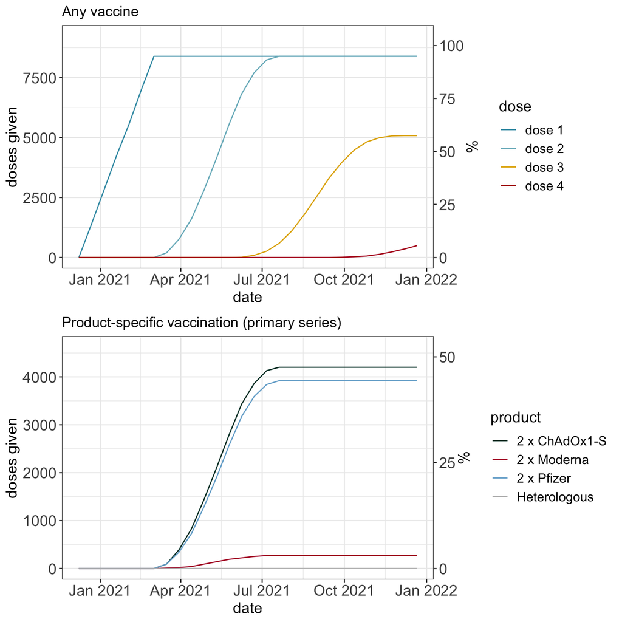

Numbers rounded to the nearest 10 before plotting.
$$\\[0.1in]$$

#### Product profile by dose

| Combination | Frequency<sup>1</sup> | Percent |
| --- | --- | --- |
| Dose 1 |  |  |
| BNT162b2 | 3920 | 46.7 |
| ChAdOx1 | 4205 | 50.1 |
| Moderna | 270 | 3.2 |
| Dose 2 |  |  |
| BNT162b2 | 3920 | 46.7 |
| ChAdOx1 | 4205 | 50.1 |
| Moderna | 270 | 3.2 |
| Dose 3 |  |  |
| BNT162b2 | 3890 | 76.6 |
| Moderna | 1140 | 22.4 |
| other | 55 | 1.1 |
| Dose 4 |  |  |
| BNT162b2 | 440 | 74.6 |
| Moderna | 150 | 25.4 |
| other | [Redacted] | [Redacted] |

<sup>*1*</sup> Any counts of <=100 grouped as 'other'; all counts rounded to nearest 5; any rounded counts <=10 redacted.

$$\\[0.05in]$$

#### Product combinations across doses

| Combination | Frequency<sup>1</sup> | Percent |
| --- | --- | --- |
| Dose 1-2 combination |  |  |
| az-az | 4205 | 50.1 |
| moderna-moderna | 270 | 3.2 |
| pfizer-pfizer | 3920 | 46.7 |
| Dose 1-2-3 combination |  |  |
| az-az-moderna | 560 | 11 |
| az-az-pfizer | 1945 | 38.3 |
| moderna-moderna-pfizer | 130 | 2.6 |
| pfizer-pfizer-moderna | 540 | 10.6 |
| pfizer-pfizer-pfizer | 1815 | 35.7 |
| other | 90 | 1.8 |

<sup>*1*</sup> Any counts of <=100 grouped as 'other'; all counts rounded to nearest 5; any rounded counts <=10 redacted.

$$\\[0.05in]$$

#### Dose interval distribution

| Variable | Count<sup>1</sup> | Percent |
| --- | --- | --- |
| Time between doses 1 and 2 |  |  |
| 10-14 weeks | 2070 | 23.4 |
| 14 weeks or more | 6325 | 71.5 |
| Not applicable (no dose given) | 450 | 5.1 |
| Time between doses 2 and 3 |  |  |
| 12-24 weeks | 5080 | 57.5 |
| Not applicable (no dose given) | 3760 | 42.5 |

<sup>*1*</sup> All counts rounded to nearest 5; any rounded counts <=10 or within <=10 of population total redacted.

$$\\[0.05in]$$

#### Covariates associated with vaccine coverage

##### Approach (1): Cox proportional hazards

Cox proportional hazards models were used to explore factors associated with completion of a 2-dose primary series via any product combination between **08 Dec 2020** and **01 Jul 2021** (at which point 2nd-dose vaccination had plateaued based on the coverage plots above). Individuals with complete data for the listed covariates were included (N = 8840, rounded to nearest 5).

Overall 2-dose prevalence as of **01 Jul 2021** was 91.5% (8085/8840, rounded to nearest 5). Follow-up was censored on the date of death, deregistration, or the end of the study period (01 Jul 2021).

Univariate models stratified by region were used to explore the potential influence of each covariate in turn. Multivariate models stratified by region, adjusting for all other covariates, were used to explore the potential influence of each covariate after adjusting for the effect of others.
$$\\[0.05in]$$

##### Univariate and multivariate model outputs

|  | n (total) | n (events)<sup>1</sup> | univariate HR | univariate lower CI | univariate upper CI | univariate p | multivariate HR (adj) | multivariate lower CI (adj) | multivariate upper CI (adj) | multivariate p (adj) |
| --- | --- | --- | --- | --- | --- | --- | --- | --- | --- | --- |
| Age |  |  |  |  |  |  |  |  |  |  |
| 16-69 (ref) | 6170 | 5630 | NA | NA | NA | NA | 1 | NA | NA | NA |
| 70-79 | 2100 | 1930 | 1.01 | 0.96 | 1.06 | 0.7013 | 1.01 | 0.96 | 1.06 | 0.7069 |
| 80-89 | 470 | 435 | 1.04 | 0.94 | 1.14 | 0.4612 | 1.03 | 0.93 | 1.13 | 0.607 |
| 90+ | [Redacted] | [Redacted] | [Redacted] | [Redacted] | [Redacted] | [Redacted] | [Redacted] | [Redacted] | [Redacted] | [Redacted] |
| Sex |  |  |  |  |  |  |  |  |  |  |
| Female (ref) | 4630 | 4255 | NA | NA | NA | NA | 1 | NA | NA | NA |
| Male | 4210 | 3830 | 0.98 | 0.93 | 1.02 | 0.2602 | 0.97 | 0.93 | 1.02 | 0.2115 |
| Ethnicity |  |  |  |  |  |  |  |  |  |  |
| White (ref) | 1750 | 1590 | NA | NA | NA | NA | 1 | NA | NA | NA |
| Mixed | 1685 | 1550 | 1.02 | 0.96 | 1.1 | 0.4998 | 1.03 | 0.96 | 1.1 | 0.4481 |
| Asian or Asian British | 1675 | 1535 | 1.03 | 0.96 | 1.11 | 0.3376 | 1.03 | 0.96 | 1.11 | 0.3476 |
| Black or Black British | 1655 | 1525 | 1.02 | 0.95 | 1.1 | 0.5013 | 1.03 | 0.96 | 1.1 | 0.4705 |
| Other ethnic groups | 1615 | 1480 | 1.03 | 0.96 | 1.11 | 0.4065 | 1.03 | 0.96 | 1.11 | 0.3815 |
| Unknown | 465 | 415 | 0.97 | 0.87 | 1.08 | 0.5228 | 0.96 | 0.87 | 1.08 | 0.5148 |
| IMD |  |  |  |  |  |  |  |  |  |  |
| 1 most deprived (ref) | 1845 | 1680 | NA | NA | NA | NA | 1 | NA | NA | NA |
| 2 | 1770 | 1640 | 1.04 | 0.97 | 1.11 | 0.319 | 1.04 | 0.97 | 1.12 | 0.2332 |
| 3 | 1770 | 1610 | 0.99 | 0.93 | 1.06 | 0.8366 | 0.99 | 0.93 | 1.06 | 0.8346 |
| 4 | 1790 | 1630 | 0.99 | 0.93 | 1.06 | 0.8497 | 1 | 0.93 | 1.07 | 0.9794 |
| 5 least deprived | 1665 | 1525 | 1.04 | 0.97 | 1.12 | 0.2228 | 1.04 | 0.97 | 1.12 | 0.2479 |
| Urban/rural |  |  |  |  |  |  |  |  |  |  |
| Urban conurbation (ref) | 2215 | 2000 | NA | NA | NA | NA | 1 | NA | NA | NA |
| Urban city or town | 2215 | 2050 | 1.08 | 1.01 | 1.14 | 0.0194 | 1.08 | 1.01 | 1.15 | 0.0178 |
| Rural town or village | 4415 | 4035 | 1.06 | 1 | 1.12 | 0.0332 | 1.06 | 1.01 | 1.12 | 0.0245 |
| CKD |  |  |  |  |  |  |  |  |  |  |
| CKD diagnostic code | 1805 | 1655 | 1.02 | 0.96 | 1.07 | 0.573 | 1.02 | 0.96 | 1.07 | 0.5669 |
| Dialysis | 4795 | 4405 | 1.02 | 0.98 | 1.07 | 0.3757 | 1.01 | 0.94 | 1.08 | 0.7856 |
| Kidney transplant | 4800 | 4365 | 0.97 | 0.93 | 1.02 | 0.2513 | 0.98 | 0.92 | 1.05 | 0.6489 |
| CKD stage 3-5 code | 1815 | 1670 | 1 | 0.95 | 1.06 | 0.8941 | 1 | 0.95 | 1.06 | 0.9141 |
| Other |  |  |  |  |  |  |  |  |  |  |
| Prior COVID | 375 | 340 | 0.97 | 0.87 | 1.08 | 0.5735 | 0.97 | 0.87 | 1.08 | 0.5601 |
| Clinically extremely vulnerable | 2650 | 2410 | 0.97 | 0.92 | 1.01 | 0.1585 | 0.97 | 0.92 | 1.01 | 0.1478 |
| Care home resident | 1805 | 1645 | 0.99 | 0.94 | 1.05 | 0.8449 | 1 | 0.94 | 1.05 | 0.8698 |
| Health and social care worker | 1735 | 1590 | 1.01 | 0.95 | 1.06 | 0.8379 | 1.01 | 0.95 | 1.06 | 0.8343 |
| End of life care | 1850 | 1670 | 0.96 | 0.91 | 1.01 | 0.1557 | 0.96 | 0.91 | 1.01 | 0.1341 |
| Housebound | 1745 | 1590 | 0.97 | 0.92 | 1.03 | 0.3263 | 0.97 | 0.92 | 1.03 | 0.3562 |
| Immunosuppression | 3145 | 2890 | 1.03 | 0.98 | 1.07 | 0.276 | 1.02 | 0.98 | 1.07 | 0.3095 |
| Chronic respiratory disease | 1780 | 1630 | 1.02 | 0.97 | 1.08 | 0.4872 | 1.02 | 0.97 | 1.08 | 0.4702 |
| Diabetes | 1780 | 1640 | 1.01 | 0.96 | 1.07 | 0.6195 | 1.02 | 0.97 | 1.08 | 0.4926 |
| Chronic liver disease | 1730 | 1610 | 1.1 | 1.04 | 1.16 | 6e-04 | 1.1 | 1.04 | 1.17 | 4e-04 |
| Chronic heart disease | 1745 | 1605 | 1.03 | 0.97 | 1.08 | 0.3575 | 1.03 | 0.97 | 1.08 | 0.3626 |
| Asplenia | 1770 | 1625 | 0.99 | 0.94 | 1.05 | 0.7587 | 0.99 | 0.94 | 1.04 | 0.6597 |
| Cancer | 1760 | 1625 | 1.02 | 0.97 | 1.08 | 0.4808 | 1.02 | 0.97 | 1.08 | 0.4864 |
| Obesity | 2605 | 2375 | 1.03 | 0.98 | 1.08 | 0.2396 | 1.03 | 0.98 | 1.08 | 0.2162 |
| Chronic neurological disease (including learning disability) | 1735 | 1595 | 0.99 | 0.94 | 1.05 | 0.7767 | 0.99 | 0.94 | 1.05 | 0.709 |
| Severe mental illness | 1770 | 1605 | 0.98 | 0.93 | 1.03 | 0.4103 | 0.98 | 0.92 | 1.03 | 0.3904 |

<sup>*1*</sup> All counts rounded to nearest 5; data redacted for any rows with rounded values of <=10 for n (total), n (events), or n (non-events), where n (non-events) is the difference between n (total) and n (events) after rounding.

$$\\[0.05in]$$

#### Plot of multivariate model outputs

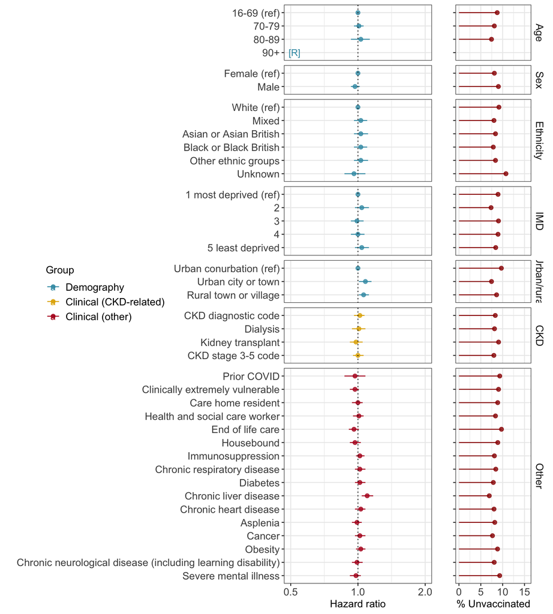

$$\\[0.05in]$$

##### Approach (2): Logistic regression

Logistic regression models were used to explore factors associated with completion of a 2-dose primary series via any product combination by **01 Jul 2021** as a binary outcome variable. Individuals with complete data for the listed covariates were included (N = 8840, rounded to nearest 5).

Overall 2-dose prevalence as of **01 Jul 2021** was 91.5% (8085/8840, rounded to nearest 5).

Univariate models were used to explore the potential influence of each covariate in turn. Multivariate models adjusting for all other covariates were used to explore the potential influence of each covariate after adjusting for the effect of others.
$$\\[0.05in]$$

##### Univariate and multivariate model outputs

|  | n (total) | n (events)<sup>1</sup> | univariate OR | univariate lower CI | univariate upper CI | univariate p | multivariate OR (adj) | multivariate lower CI (adj) | multivariate upper CI (adj) | multivariate p (adj) |
| --- | --- | --- | --- | --- | --- | --- | --- | --- | --- | --- |
| Age |  |  |  |  |  |  |  |  |  |  |
| 16-69 (ref) | 6170 | 5630 | 1 | NA | NA | NA | 1 | NA | NA | NA |
| 70-79 | 2100 | 1930 | 1.07 | 0.9 | 1.28 | 0.4508 | 1.07 | 0.89 | 1.28 | 0.4768 |
| 80-89 | 470 | 435 | 1.17 | 0.84 | 1.69 | 0.3791 | 1.14 | 0.81 | 1.64 | 0.4791 |
| 90+ | [Redacted] | [Redacted] | [Redacted] | [Redacted] | [Redacted] | [Redacted] | [Redacted] | [Redacted] | [Redacted] | [Redacted] |
| Sex |  |  |  |  |  |  |  |  |  |  |
| Female (ref) | 4630 | 4255 | 1 | NA | NA | NA | 1 | NA | NA | NA |
| Male | 4210 | 3830 | 0.88 | 0.76 | 1.02 | 0.1009 | 0.88 | 0.75 | 1.02 | 0.0856 |
| Ethnicity |  |  |  |  |  |  |  |  |  |  |
| White (ref) | 1750 | 1590 | 1 | NA | NA | NA | 1 | NA | NA | NA |
| Mixed | 1685 | 1550 | 1.17 | 0.92 | 1.48 | 0.2025 | 1.18 | 0.93 | 1.5 | 0.1674 |
| Asian or Asian British | 1675 | 1535 | 1.13 | 0.89 | 1.43 | 0.3075 | 1.14 | 0.9 | 1.44 | 0.2936 |
| Black or Black British | 1655 | 1525 | 1.2 | 0.94 | 1.53 | 0.1356 | 1.22 | 0.96 | 1.55 | 0.1099 |
| Other ethnic groups | 1615 | 1480 | 1.13 | 0.89 | 1.44 | 0.3103 | 1.15 | 0.91 | 1.46 | 0.2479 |
| Unknown | 465 | 415 | 0.86 | 0.62 | 1.21 | 0.3592 | 0.86 | 0.62 | 1.21 | 0.3816 |
| IMD |  |  |  |  |  |  |  |  |  |  |
| 1 most deprived (ref) | 1845 | 1680 | 1 | NA | NA | NA | 1 | NA | NA | NA |
| 2 | 1770 | 1640 | 1.24 | 0.98 | 1.58 | 0.0785 | 1.24 | 0.97 | 1.57 | 0.0826 |
| 3 | 1770 | 1610 | 1 | 0.8 | 1.26 | 0.9797 | 0.99 | 0.78 | 1.24 | 0.9026 |
| 4 | 1790 | 1630 | 1 | 0.8 | 1.26 | 0.9935 | 1.01 | 0.8 | 1.27 | 0.943 |
| 5 least deprived | 1665 | 1525 | 1.08 | 0.85 | 1.36 | 0.5337 | 1.07 | 0.84 | 1.35 | 0.5968 |
| Urban/rural |  |  |  |  |  |  |  |  |  |  |
| Urban conurbation (ref) | 2215 | 2000 | 1 | NA | NA | NA | 1 | NA | NA | NA |
| Urban city or town | 2215 | 2050 | 1.35 | 1.09 | 1.67 | 0.0055 | 1.37 | 1.11 | 1.7 | 0.0038 |
| Rural town or village | 4415 | 4035 | 1.14 | 0.96 | 1.36 | 0.1344 | 1.16 | 0.97 | 1.38 | 0.0998 |
| CKD |  |  |  |  |  |  |  |  |  |  |
| CKD diagnostic code | 1805 | 1655 | 1.03 | 0.86 | 1.25 | 0.745 | 1.02 | 0.85 | 1.24 | 0.8 |
| Dialysis | 4795 | 4405 | 1.13 | 0.97 | 1.31 | 0.1036 | 1.08 | 0.86 | 1.37 | 0.4993 |
| Kidney transplant | 4800 | 4365 | 0.87 | 0.75 | 1.02 | 0.0788 | 0.94 | 0.74 | 1.19 | 0.5777 |
| CKD stage 3-5 code | 1815 | 1670 | 1.09 | 0.9 | 1.32 | 0.377 | 1.09 | 0.9 | 1.32 | 0.3805 |
| Other |  |  |  |  |  |  |  |  |  |  |
| Prior COVID | 375 | 340 | 0.9 | 0.64 | 1.31 | 0.5737 | 0.91 | 0.65 | 1.32 | 0.6047 |
| Clinically extremely vulnerable | 2650 | 2410 | 0.91 | 0.78 | 1.07 | 0.2473 | 0.91 | 0.77 | 1.06 | 0.2247 |
| Care home resident | 1805 | 1645 | 0.95 | 0.79 | 1.14 | 0.5475 | 0.95 | 0.79 | 1.15 | 0.5925 |
| Health and social care worker | 1735 | 1590 | 1.01 | 0.84 | 1.22 | 0.9457 | 1 | 0.83 | 1.21 | 0.9824 |
| End of life care | 1850 | 1670 | 0.84 | 0.71 | 1 | 0.0533 | 0.83 | 0.7 | 1 | 0.0449 |
| Housebound | 1745 | 1590 | 0.96 | 0.8 | 1.16 | 0.6483 | 0.97 | 0.8 | 1.17 | 0.7172 |
| Immunosuppression | 3145 | 2890 | 1.09 | 0.94 | 1.28 | 0.2606 | 1.1 | 0.94 | 1.29 | 0.2524 |
| Chronic respiratory disease | 1780 | 1630 | 1.01 | 0.84 | 1.22 | 0.8949 | 1.01 | 0.84 | 1.22 | 0.9377 |
| Diabetes | 1780 | 1640 | 1.12 | 0.93 | 1.36 | 0.2372 | 1.15 | 0.95 | 1.39 | 0.1639 |
| Chronic liver disease | 1730 | 1610 | 1.33 | 1.09 | 1.64 | 0.0054 | 1.36 | 1.11 | 1.67 | 0.0035 |
| Chronic heart disease | 1745 | 1605 | 1.1 | 0.91 | 1.34 | 0.3288 | 1.1 | 0.91 | 1.34 | 0.3222 |
| Asplenia | 1770 | 1625 | 1.03 | 0.86 | 1.25 | 0.7308 | 1.04 | 0.86 | 1.26 | 0.7104 |
| Cancer | 1760 | 1625 | 1.17 | 0.97 | 1.42 | 0.1162 | 1.17 | 0.97 | 1.43 | 0.1115 |
| Obesity | 2605 | 2375 | 0.96 | 0.82 | 1.13 | 0.6133 | 0.96 | 0.82 | 1.13 | 0.6361 |
| Chronic neurological disease (including learning disability) | 1735 | 1595 | 1.07 | 0.89 | 1.31 | 0.4608 | 1.07 | 0.89 | 1.31 | 0.4666 |
| Severe mental illness | 1770 | 1605 | 0.9 | 0.75 | 1.08 | 0.2367 | 0.88 | 0.74 | 1.06 | 0.1748 |

<sup>*1*</sup> All counts rounded to nearest 5; data redacted for any rows with rounded values of <=10 for n (total), n (events), or n (non-events), where n (non-events) is the difference between n (total) and n (events) after rounding.

$$\\[0.1in]$$

#### Plot of multivariate model outputs

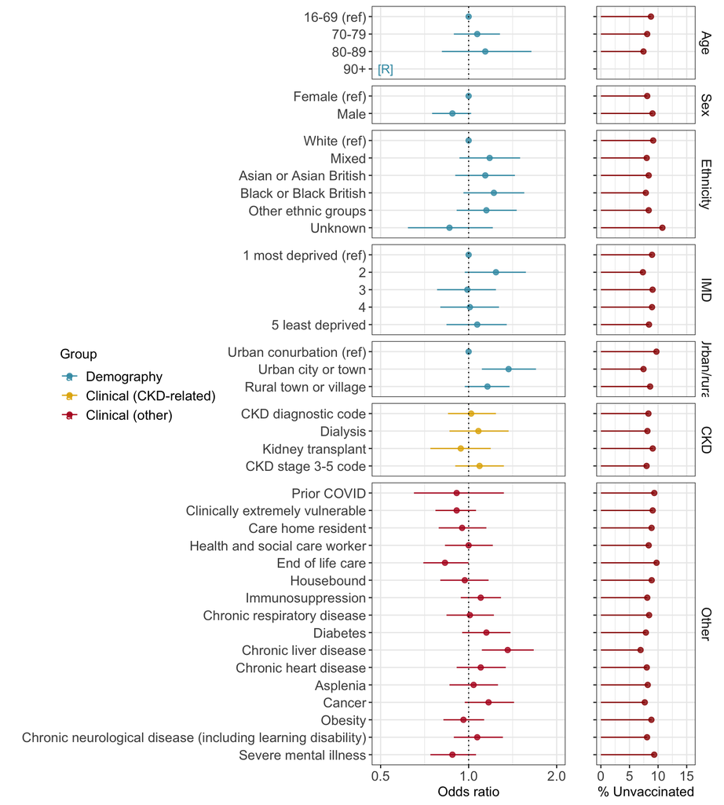